# SR_02_RLTD_ORG_DMCL_STATE

Legal domicile (state) · Code report

## Overview

**Description**

Legal Domicile - State

**Table**

`SR-P02-T01-ID-RLTD-TAX-EXEMPED-ORGS` (many)

**Location code**

`SCHED-R-PART-02-COL-C`

**Family**

`SCHED-R-PART-02-COL-C` · siblings: SR_02_RLTD_ORG_DMCL_CNTR

**Data type**

text (xsd: StateType)

**Scope**

PC

**Status**

unreviewed

3

xpaths mapped (2 observed)

827,259

filings with a value

2009–2024

tax years observed

2

open flags (0 errors)

## Flags

| Severity | Flag | Xpath | Detail |
| --- | --- | --- | --- |
| ⓘ info | `MANY_NOT_REPEATING` | IRS990ScheduleR/IdRelatedTaxExemptOrgGrp/LegalDomicileStateCd | many-to-one table, but 51% of values sit in no repeating element |
| ⓘ info | `UNOBSERVED` | IRS990ScheduleR/Form990ScheduleRPartII/LegalDomicile/State | never observed in TY2009-2024 filings |

## Xpaths

All mapped xpaths (under /Return/ReturnData or /Return/ReturnHeader), oldest first. Charts label each series by its xpath.

[output not shown]

## Coverage

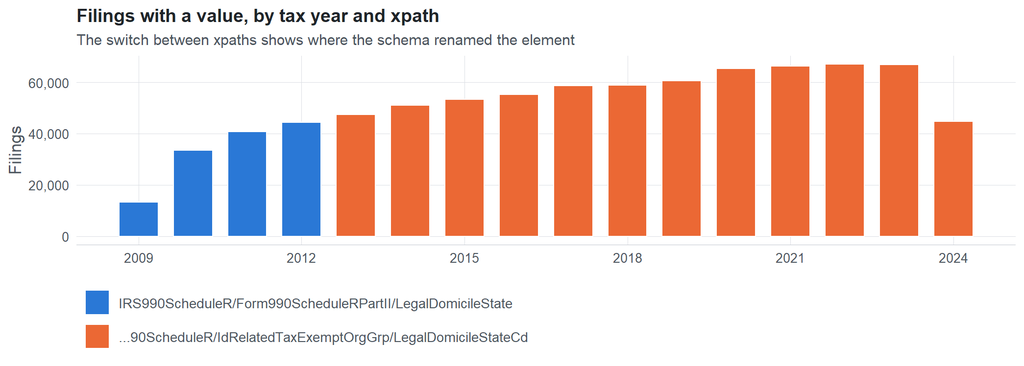

**Table view**

Table view: filings by tax year and series

| Tax year | IRS990ScheduleR/Form990ScheduleRPartII/LegalDomicileState | …90ScheduleR/IdRelatedTaxExemptOrgGrp/LegalDomicileStateCd |
| --- | --- | --- |
| 2009 | 13,263 | 0 |
| 2010 | 33,427 | 0 |
| 2011 | 40,845 | 0 |
| 2012 | 44,424 | 0 |
| 2013 | 0 | 47,508 |
| 2014 | 0 | 50,987 |
| 2015 | 0 | 53,348 |
| 2016 | 0 | 55,229 |
| 2017 | 0 | 58,647 |
| 2018 | 0 | 58,892 |
| 2019 | 0 | 60,543 |
| 2020 | 0 | 65,314 |
| 2021 | 0 | 66,210 |
| 2022 | 0 | 67,007 |
| 2023 | 0 | 66,887 |
| 2024 | 0 | 44,728 |

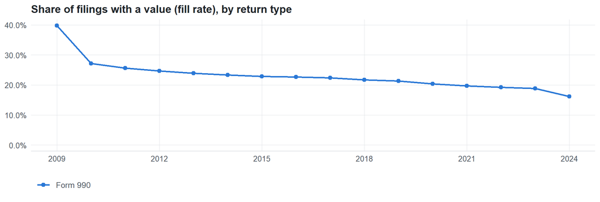

**Table view**

Table view: fill rate

| Tax year | Return type | Filings | All filings | Fill rate |
| --- | --- | --- | --- | --- |
| 2009 | Form 990 | 13,263 | 33,311 | 39.82% |
| 2010 | Form 990 | 33,427 | 123,025 | 27.17% |
| 2011 | Form 990 | 40,845 | 159,504 | 25.61% |
| 2012 | Form 990 | 44,424 | 179,688 | 24.72% |
| 2013 | Form 990 | 47,508 | 198,855 | 23.89% |
| 2014 | Form 990 | 50,987 | 218,619 | 23.32% |
| 2015 | Form 990 | 53,348 | 233,519 | 22.85% |
| 2016 | Form 990 | 55,229 | 243,903 | 22.64% |
| 2017 | Form 990 | 58,647 | 261,612 | 22.42% |
| 2018 | Form 990 | 58,892 | 271,442 | 21.70% |
| 2019 | Form 990 | 60,543 | 283,694 | 21.34% |
| 2020 | Form 990 | 65,314 | 320,342 | 20.39% |
| 2021 | Form 990 | 66,210 | 336,480 | 19.68% |
| 2022 | Form 990 | 67,007 | 349,055 | 19.20% |
| 2023 | Form 990 | 66,887 | 354,768 | 18.85% |
| 2024 | Form 990 | 44,728 | 277,298 | 16.13% |

## Repeating groups

Table cardinality in the concordance: **many**. 2 of 2 observed xpaths repeat within a filing.

Repeating element each xpath was observed in (from the raw indexed xpath)

| Xpath | Repeating element | Filings (summed over years) |
| --- | --- | --- |
| IRS990ScheduleR/Form990ScheduleRPartII/LegalDomicileState | (none) | 63684 |
| IRS990ScheduleR/Form990ScheduleRPartII/LegalDomicileState | IRS990ScheduleR/Form990ScheduleRPartII | 68275 |
| IRS990ScheduleR/IdRelatedTaxExemptOrgGrp/LegalDomicileStateCd | (none) | 357741 |
| IRS990ScheduleR/IdRelatedTaxExemptOrgGrp/LegalDomicileStateCd | IRS990ScheduleR/IdRelatedTaxExemptOrgGrp | 337559 |

## Values

| Result | Check | Detail |
| --- | --- | --- |
| ✓ pass | Small code list | up to 66 distinct values per xpath and year |
| ✓ pass | Codes share one format | 100% have the shape AA |
| ✓ pass | Consistent letter case | 0.0% of values are lower case |

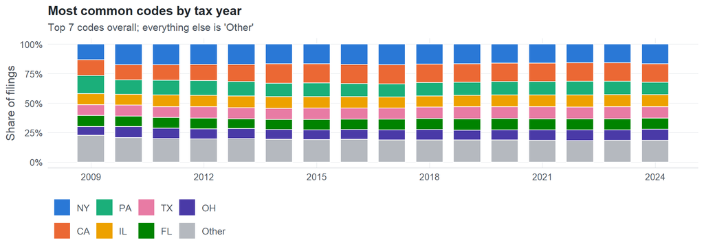

**Table view**

Table view: filings by code and tax year

| tax_year | NY | CA | PA | IL | TX | FL | OH | Other |
| --- | --- | --- | --- | --- | --- | --- | --- | --- |
| 2009 | 1,175 | 1,167 | 1,351 | 835 | 786 | 828 | 651 | 1,993 |
| 2010 | 3,936 | 2,868 | 2,768 | 2,053 | 2,081 | 2,025 | 2,076 | 4,654 |
| 2011 | 4,749 | 3,613 | 3,399 | 2,666 | 2,487 | 2,483 | 2,391 | 5,443 |
| 2012 | 5,144 | 4,023 | 3,731 | 2,852 | 2,822 | 2,737 | 2,503 | 5,833 |
| 2013 | 5,503 | 4,584 | 3,864 | 3,144 | 2,948 | 2,672 | 2,697 | 6,288 |
| 2014 | 5,791 | 5,639 | 4,004 | 3,376 | 3,238 | 3,009 | 2,825 | 6,644 |
| 2015 | 6,088 | 5,996 | 4,191 | 3,581 | 3,507 | 3,263 | 3,055 | 6,926 |
| 2016 | 6,577 | 6,211 | 4,332 | 3,661 | 3,548 | 3,400 | 3,187 | 7,369 |
| 2017 | 7,081 | 6,621 | 4,503 | 3,820 | 3,835 | 3,673 | 3,465 | 7,597 |
| 2018 | 7,259 | 6,718 | 4,779 | 4,051 | 4,125 | 4,107 | 3,680 | 8,035 |
| 2019 | 7,276 | 6,867 | 4,960 | 4,222 | 4,466 | 4,204 | 3,731 | 8,153 |
| 2020 | 7,504 | 7,195 | 5,254 | 4,699 | 4,608 | 4,428 | 4,013 | 8,613 |
| 2021 | 7,579 | 7,235 | 5,350 | 4,729 | 4,721 | 4,420 | 4,103 | 8,679 |
| 2022 | 7,534 | 7,304 | 5,447 | 4,823 | 4,747 | 4,499 | 4,191 | 8,597 |
| 2023 | 7,485 | 7,340 | 5,396 | 4,828 | 4,755 | 4,443 | 4,166 | 8,702 |
| 2024 | 4,923 | 4,579 | 3,072 | 3,005 | 2,801 | 2,697 | 2,769 | 5,411 |

Code frequencies (all xpaths, all years)

| Code | Filings | Share |
| --- | --- | --- |
| NY | 95,604 | 16.7% |
| CA | 87,960 | 15.3% |
| PA | 66,401 | 11.6% |
| IL | 56,345 | 9.8% |
| TX | 55,475 | 9.7% |
| FL | 52,888 | 9.2% |
| OH | 49,503 | 8.6% |
| MA | 38,168 | 6.7% |
| MO | 28,070 | 4.9% |
| MI | 16,995 | 3.0% |
| DC | 16,127 | 2.8% |
| GA | 7,321 | 1.3% |
| NJ | 2,256 | 0.4% |

## Examples

| Tax year | Return | Xpath | Organization | Value | Source |
| --- | --- | --- | --- | --- | --- |
| 2024 | 990 | IRS990ScheduleR/IdRelatedTaxExemptOrgGrp/LegalDomicileStateCd | RISEWELL COMMUNITY SERVICES INC FKA | NY | [XML](https://gt990datalake-rawdata.s3.amazonaws.com/EfileData/XmlFiles/202610589349301811_public.xml) |
| 2023 | 990 | IRS990ScheduleR/IdRelatedTaxExemptOrgGrp/LegalDomicileStateCd | ARIZONA YOUTH PARTNERSHIP | AZ | [XML](https://gt990datalake-rawdata.s3.amazonaws.com/EfileData/XmlFiles/202510809349301201_public.xml) |
| 2022 | 990 | IRS990ScheduleR/IdRelatedTaxExemptOrgGrp/LegalDomicileStateCd | RIVER GARDEN GERIATRIC | FL | [XML](https://gt990datalake-rawdata.s3.amazonaws.com/EfileData/XmlFiles/202313079349302866_public.xml) |
| 2021 | 990 | IRS990ScheduleR/IdRelatedTaxExemptOrgGrp/LegalDomicileStateCd | CAMP JOHN MARC FOUNDATION INC | TX | [XML](https://gt990datalake-rawdata.s3.amazonaws.com/EfileData/XmlFiles/202241039349300339_public.xml) |
| 2020 | 990 | IRS990ScheduleR/IdRelatedTaxExemptOrgGrp/LegalDomicileStateCd | The CareSource Foundation | OH | [XML](https://gt990datalake-rawdata.s3.amazonaws.com/EfileData/XmlFiles/202123169349306582_public.xml) |
| 2019 | 990 | IRS990ScheduleR/IdRelatedTaxExemptOrgGrp/LegalDomicileStateCd | JOBE | CA | [XML](https://gt990datalake-rawdata.s3.amazonaws.com/EfileData/XmlFiles/202011139349301211_public.xml) |
| 2018 | 990 | IRS990ScheduleR/IdRelatedTaxExemptOrgGrp/LegalDomicileStateCd | UA LOCAL NO 159 | CA | [XML](https://gt990datalake-rawdata.s3.amazonaws.com/EfileData/XmlFiles/202000509349301025_public.xml) |
| 2017 | 990 | IRS990ScheduleR/IdRelatedTaxExemptOrgGrp/LegalDomicileStateCd | TELEOS PREPARATORY ACADEMY | AZ | [XML](https://gt990datalake-rawdata.s3.amazonaws.com/EfileData/XmlFiles/201901339349307160_public.xml) |
| 2016 | 990 | IRS990ScheduleR/IdRelatedTaxExemptOrgGrp/LegalDomicileStateCd | METROWEST CHAMBER OF COMMERCE INC | MA | [XML](https://gt990datalake-rawdata.s3.amazonaws.com/EfileData/XmlFiles/201733109349301908_public.xml) |
| 2015 | 990 | IRS990ScheduleR/IdRelatedTaxExemptOrgGrp/LegalDomicileStateCd | STAPELEY HALL | PA | [XML](https://gt990datalake-rawdata.s3.amazonaws.com/EfileData/XmlFiles/201623199349306982_public.xml) |
| 2014 | 990 | IRS990ScheduleR/IdRelatedTaxExemptOrgGrp/LegalDomicileStateCd | MERCY PORTFOLIO SERVICES | CA | [XML](https://gt990datalake-rawdata.s3.amazonaws.com/EfileData/XmlFiles/201513159349303196_public.xml) |
| 2013 | 990 | IRS990ScheduleR/IdRelatedTaxExemptOrgGrp/LegalDomicileStateCd | CAPITAL CITY PRESS ET AL HEALTH | LA | [XML](https://gt990datalake-rawdata.s3.amazonaws.com/EfileData/XmlFiles/201503289349300110_public.xml) |

## Reviewer checklist

- The definition matches the form line and instructions for every xpath’s schema years.
- Every xpath pooled here measures the same thing on the 990 and 990-EZ (close enough for analysis).
- The coverage chart has no unexplained gaps or jumps between tax years.
- Each open flag is fixed, or accepted with a note in validation_log.csv.
- Every code is valid for the list the form uses (state, country, valuation method, …).
- The code list and its meaning did not change across schema versions.
- Codes are stored as text, so values like leading zeros are preserved.

Record the review as a row in `inst/extdata/src/validation_log.csv` (variable_name, reviewer, date, status, note). Evidence built 2026-09-23 17:09:04 MST from the ef2 DuckDB builds, TY2009–2024.